# Analysis of NOAA Storm Data

John ARNZEN

## Synopsis

Our task for this assignment was to analyze the NOAA Storm Data database of the United States, looking for the types of weather events which most cause the most monetary damages to property and crops, and the weather events which cause the most fatalities and injuries.

The data stretch from 1950 to 2011 with a wide variety of variations of data quality and number of observations through the years. Minimal attempts were made to clarify the data due to scope and time—this should be considered a first pass at an analysis.

That said, we found that flooding and tornadoes were the most impactful culprits of the weather events across the US over the duration analyzed. Flooding caused the most property and crop damages, while tornadoes caused the most fatalities and injuries.

## Data Processing

```r
## load the libraries we'll use to process the data
library(data.table, warn.conflicts = FALSE)
library(dplyr, warn.conflicts = FALSE)
library(ggplot2, warn.conflicts = FALSE)
```

```r
## read the compressed data into a data frame
df_orig <- read.csv("StormData.csv.bz2")

## check the structure of the data and review their column names
str(df_orig)
```

```
## 'data.frame':    902297 obs. of  37 variables:
##  $ STATE__   : num  1 1 1 1 1 1 1 1 1 1 ...
##  $ BGN_DATE  : Factor w/ 16335 levels "1/1/1966 0:00:00",..: 6523 6523 4242 11116 2224 2224 2260 383 3980 3980 ...
##  $ BGN_TIME  : Factor w/ 3608 levels "00:00:00 AM",..: 272 287 2705 1683 2584 3186 242 1683 3186 3186 ...
##  $ TIME_ZONE : Factor w/ 22 levels "ADT","AKS","AST",..: 7 7 7 7 7 7 7 7 7 7 ...
##  $ COUNTY    : num  97 3 57 89 43 77 9 123 125 57 ...
##  $ COUNTYNAME: Factor w/ 29601 levels "","5NM E OF MACKINAC BRIDGE TO PRESQUE ISLE LT MI",..: 13513 1873 4598 10592 4372 10094 1973 23873 24418 4598 ...
##  $ STATE     : Factor w/ 72 levels "AK","AL","AM",..: 2 2 2 2 2 2 2 2 2 2 ...
##  $ EVTYPE    : Factor w/ 985 levels "   HIGH SURF ADVISORY",..: 834 834 834 834 834 834 834 834 834 834 ...
##  $ BGN_RANGE : num  0 0 0 0 0 0 0 0 0 0 ...
##  $ BGN_AZI   : Factor w/ 35 levels "","  N"," NW",..: 1 1 1 1 1 1 1 1 1 1 ...
##  $ BGN_LOCATI: Factor w/ 54429 levels ""," Christiansburg",..: 1 1 1 1 1 1 1 1 1 1 ...
##  $ END_DATE  : Factor w/ 6663 levels "","1/1/1993 0:00:00",..: 1 1 1 1 1 1 1 1 1 1 ...
##  $ END_TIME  : Factor w/ 3647 levels ""," 0900CST",..: 1 1 1 1 1 1 1 1 1 1 ...
##  $ COUNTY_END: num  0 0 0 0 0 0 0 0 0 0 ...
```

[output cut: 23 more lines]

```r
## quick summary of the data (mostly to identify columns with NAs
## and other anomolies)
summary(df_orig)
```

```
##     STATE__                  BGN_DATE             BGN_TIME
##  Min.   : 1.0   5/25/2011 0:00:00:  1202   12:00:00 AM: 10163
##  1st Qu.:19.0   4/27/2011 0:00:00:  1193   06:00:00 PM:  7350
##  Median :30.0   6/9/2011 0:00:00 :  1030   04:00:00 PM:  7261
##  Mean   :31.2   5/30/2004 0:00:00:  1016   05:00:00 PM:  6891
##  3rd Qu.:45.0   4/4/2011 0:00:00 :  1009   12:00:00 PM:  6703
##  Max.   :95.0   4/2/2006 0:00:00 :   981   03:00:00 PM:  6700
##                 (Other)          :895866   (Other)    :857229
##    TIME_ZONE          COUNTY           COUNTYNAME         STATE
##  CST    :547493   Min.   :  0.0   JEFFERSON :  7840   TX     : 83728
##  EST    :245558   1st Qu.: 31.0   WASHINGTON:  7603   KS     : 53440
##  MST    : 68390   Median : 75.0   JACKSON   :  6660   OK     : 46802
##  PST    : 28302   Mean   :100.6   FRANKLIN  :  6256   MO     : 35648
##  AST    :  6360   3rd Qu.:131.0   LINCOLN   :  5937   IA     : 31069
##  HST    :  2563   Max.   :873.0   MADISON   :  5632   NE     : 30271
##  (Other):  3631                   (Other)   :862369   (Other):621339
##                EVTYPE         BGN_RANGE           BGN_AZI
##  HAIL             :288661   Min.   :   0.000          :547332
##  TSTM WIND        :219940   1st Qu.:   0.000   N      : 86752
##  THUNDERSTORM WIND: 82563   Median :   0.000   W      : 38446
##  TORNADO          : 60652   Mean   :   1.484   S      : 37558
##  FLASH FLOOD      : 54277   3rd Qu.:   1.000   E      : 33178
##  FLOOD            : 25326   Max.   :3749.000   NW     : 24041
##  (Other)          :170878                      (Other):134990
##          BGN_LOCATI                  END_DATE             END_TIME
##               :287743                    :243411              :238978
##  COUNTYWIDE   : 19680   4/27/2011 0:00:00:  1214   06:00:00 PM:  9802
##  Countywide   :   993   5/25/2011 0:00:00:  1196   05:00:00 PM:  8314
##  SPRINGFIELD  :   843   6/9/2011 0:00:00 :  1021   04:00:00 PM:  8104
##  SOUTH PORTION:   810   4/4/2011 0:00:00 :  1007   12:00:00 PM:  7483
##  NORTH PORTION:   784   5/30/2004 0:00:00:   998   11:59:00 PM:  7184
##  (Other)      :591444   (Other)          :653450   (Other)    :622432
##    COUNTY_END COUNTYENDN       END_RANGE           END_AZI
##  Min.   :0    Mode:logical   Min.   :  0.0000          :724837
##  1st Qu.:0    NA's:902297    1st Qu.:  0.0000   N      : 28082
##  Median :0                   Median :  0.0000   S      : 22510
##  Mean   :0                   Mean   :  0.9862   W      : 20119
##  3rd Qu.:0                   3rd Qu.:  0.0000   E      : 20047
##  Max.   :0                   Max.   :925.0000   NE     : 14606
##                                                 (Other): 72096
```

[output cut: 41 more lines]

```
##  Min.   :   0   Min.   :-14451   Min.   :   0   Min.   :-14455
##  1st Qu.:2802   1st Qu.:  7247   1st Qu.:   0   1st Qu.:     0
##  Median :3540   Median :  8707   Median :   0   Median :     0
##  Mean   :2875   Mean   :  6940   Mean   :1452   Mean   :  3509
##  3rd Qu.:4019   3rd Qu.:  9605   3rd Qu.:3549   3rd Qu.:  8735
##  Max.   :9706   Max.   : 17124   Max.   :9706   Max.   :106220
##  NA's   :47                      NA's   :40
##                                            REMARKS           REFNUM
##                                                :287433   Min.   :     1
##                                                : 24013   1st Qu.:225575
##  Trees down.\n                                 :  1110   Median :451149
##  Several trees were blown down.\n              :   568   Mean   :451149
##  Trees were downed.\n                          :   446   3rd Qu.:676723
##  Large trees and power lines were blown down.\n:   432   Max.   :902297
##  (Other)                                       :588295
```

```r
## turn the data frame into a data table for faster & easier processing
dt <- as.data.table(df_orig)
```

```r
## what are the levels of EVTYPE?
levels(dt$EVTYPE)
```

```
##   [1] "   HIGH SURF ADVISORY"          " COASTAL FLOOD"
##   [3] " FLASH FLOOD"                   " LIGHTNING"
##   [5] " TSTM WIND"                     " TSTM WIND (G45)"
##   [7] " WATERSPOUT"                    " WIND"
##   [9] "?"                              "ABNORMAL WARMTH"
##  [11] "ABNORMALLY DRY"                 "ABNORMALLY WET"
##  [13] "ACCUMULATED SNOWFALL"           "AGRICULTURAL FREEZE"
##  [15] "APACHE COUNTY"                  "ASTRONOMICAL HIGH TIDE"
##  [17] "ASTRONOMICAL LOW TIDE"          "AVALANCE"
##  [19] "AVALANCHE"                      "BEACH EROSIN"
##  [21] "Beach Erosion"                  "BEACH EROSION"
##  [23] "BEACH EROSION/COASTAL FLOOD"    "BEACH FLOOD"
##  [25] "BELOW NORMAL PRECIPITATION"     "BITTER WIND CHILL"
##  [27] "BITTER WIND CHILL TEMPERATURES" "Black Ice"
##  [29] "BLACK ICE"                      "BLIZZARD"
```

[output cut: 478 more lines]

```r
## any EVTYPE NAs?
dt[is.na(EVTYPE), .N] ## .N = number of rows; provided by data.table
```

```
## [1] 0
```

```r
## trim and upcase the EVTYPEs to normalize and prepare to group them
normalizeFactors <- function(f) factor(toupper(trimws(f)))
dt$EVTYPE <- normalizeFactors(dt$EVTYPE)
```

```r
## what are the most common events?
events <- dt %>%
    group_by(EVTYPE) %>%
    tally(sort = TRUE)
```

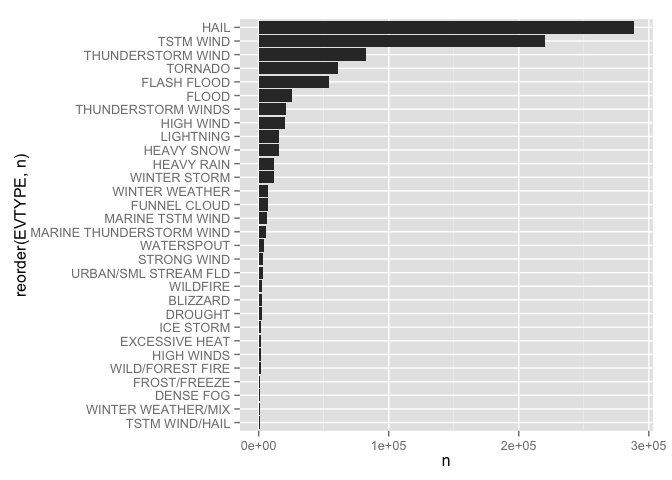

```r
## quick plot of the most common events
qplot(x = reorder(EVTYPE, n), y = n,
      data = events[n >= mean(n)],
      geom="bar", stat="identity") +
    coord_flip()
```

**Figure #1**: Plot of most common weather events in the NOAA dataset

```r
## events compared and merged with the NOAA official events
# noaa_events <- data.frame(EVENTS = toupper(trimws(readLines("NOAA-events.txt"))))
noaa_events <- data.frame(EVENTS = factor(c("ASTRONOMICAL LOW TIDE", "AVALANCHE", "BLIZZARD", "COASTAL FLOOD", "COLD/WIND CHILL", "DEBRIS FLOW", "DENSE FOG",
"DENSE SMOKE", "DROUGHT", "DUST DEVIL", "DUST STORM", "EXCESSIVE HEAT",
"EXTREME COLD/WIND CHILL", "FLASH FLOOD", "FLOOD", "FREEZING FOG",
"FROST/FREEZE", "FUNNEL CLOUD", "HAIL", "HEAT", "HEAVY RAIN",
"HEAVY SNOW", "HIGH SURF", "HIGH WIND", "HURRICANE (TYPHOON)",
"ICE STORM", "LAKE-EFFECT SNOW", "LAKESHORE FLOOD", "LIGHTNING",
"MARINE HAIL", "MARINE HIGH WIND", "MARINE STRONG WIND", "MARINE THUNDERSTORM WIND", "RIP CURRENT", "SEICHE", "SLEET", "STORM SURGE/TIDE", "STRONG WIND",
"THUNDERSTORM WIND", "TORNADO", "TROPICAL DEPRESSION", "TROPICAL STORM",
"TSUNAMI", "VOLCANIC ASH", "WATERSPOUT", "WILDFIRE", "WINTER STORM",
"WINTER WEATHER")))

dt_merged <- merge(events, noaa_events, by.x = "EVTYPE", by.y="EVENTS")
```

```r
## quick plot of the official event counts
# qplot(x = reorder(EVTYPE, n), y = n,
#       data = dt_merged,
#       geom="bar", stat="identity") +
#    coord_flip()
```

```r
## check for NAs in the damage-related columns
dt[is.na(PROPDMG) | is.na(CROPDMG), .N]
```

```
## [1] 0
```

```r
dt[is.na(PROPDMGEXP) | is.na(CROPDMGEXP), .N]
```

```
## [1] 0
```

```r
## check the levels of the *EXP columns, looking for anomolies
levels(dt$PROPDMGEXP)
```

```
##  [1] ""  "-" "?" "+" "0" "1" "2" "3" "4" "5" "6" "7" "8" "B" "h" "H" "K"
## [18] "m" "M"
```

```r
levels(dt$CROPDMGEXP)
```

```
## [1] ""  "?" "0" "2" "B" "k" "K" "m" "M"
```

```r
## normalize the *EXP factors like we did for EVTYPE
dt$PROPDMGEXP <- normalizeFactors(dt$PROPDMGEXP)
dt$CROPDMGEXP <- normalizeFactors(dt$CROPDMGEXP)
```

```r
## calculate the damages per event type
expToValue <- function(exp) switch(as.character(exp),
                                   H = 100,
                                   K = 1000,
                                   M = 1e6,
                                   B = 1e9,
                                   1)

damages <- dt[PROPDMG > 0 | CROPDMG > 0] %>%
    mutate(PROPDMGEXP_value = sapply(PROPDMGEXP, expToValue),
           CROPDMGEXP_value = sapply(CROPDMGEXP, expToValue)) %>%
    mutate(PROPDMG_value = PROPDMG * PROPDMGEXP_value,
           CROPDMG_value = CROPDMG * CROPDMGEXP_value,
           DMG_total = PROPDMG_value + CROPDMG_value) %>%
    group_by(EVTYPE) %>%
    summarise(total_damages = sum(DMG_total))

## get a summary of the damages
summary(damages)
```

```
##                     EVTYPE    total_damages
##  ?                     :  1   Min.   :0.000e+00
##  AGRICULTURAL FREEZE   :  1   1st Qu.:1.512e+04
##  APACHE COUNTY         :  1   Median :3.306e+05
##  ASTRONOMICAL HIGH TIDE:  1   Mean   :1.209e+09
##  ASTRONOMICAL LOW TIDE :  1   3rd Qu.:7.248e+06
##  AVALANCHE             :  1   Max.   :1.503e+11
##  (Other)               :388
```

```r
## calculate the fatalites and injuries per event type
lives <- dt[FATALITIES > 0 | INJURIES > 0] %>%
    group_by(EVTYPE) %>%
    summarise(total_fatalities = sum(FATALITIES),
              total_injuries = sum(INJURIES)) %>%
    mutate(total_lives = total_fatalities + total_injuries)

## get a summary of the fatalities and injuries
summary(lives)
```

```
##           EVTYPE    total_fatalities  total_injuries     total_lives
##  AVALANCE    :  1   Min.   :   0.00   Min.   :    0.0   Min.   :    1.0
##  AVALANCHE   :  1   1st Qu.:   1.00   1st Qu.:    0.0   1st Qu.:    2.0
##  BLACK ICE   :  1   Median :   2.00   Median :    3.0   Median :    6.0
##  BLIZZARD    :  1   Mean   :  73.88   Mean   :  685.5   Mean   :  759.4
##  BLOWING SNOW:  1   3rd Qu.:  13.00   3rd Qu.:   40.0   3rd Qu.:   51.0
##  BRUSH FIRE  :  1   Max.   :5633.00   Max.   :91346.0   Max.   :96979.0
##  (Other)     :199
```

## Results

1. Across the United States, which types of events (as indicated in the `EVTYPE` variable) are most harmful with respect to population health?

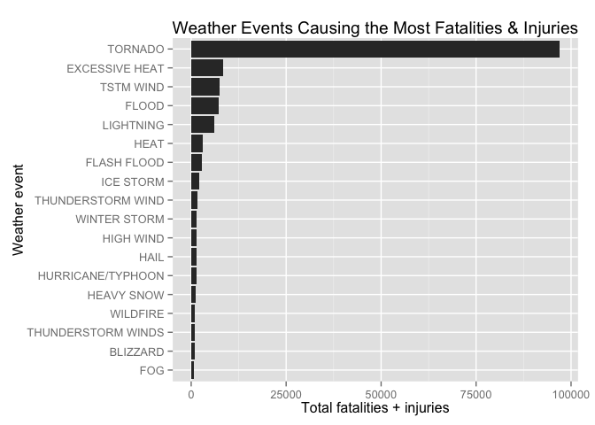

```r
## quick plot of the top life-impacting events and their impacts
qplot(x = reorder(EVTYPE, total_lives), y = total_lives,
      data = lives[total_lives >= mean(total_lives)],
      geom = "bar", stat = "identity") +
    coord_flip() +
    labs(title = "Weather Events Causing the Most Fatalities & Injuries",
         x = "Weather event",
         y = "Total fatalities + injuries")
```

**Figure #2**: Plot of total fatalities & injuries by weather event

We see that tornadoes caused the most fatalities and injuries by far, and that floods were the fourth cause of impacts to lives.

2. Across the United States, which types of events have the greatest economic consequences?

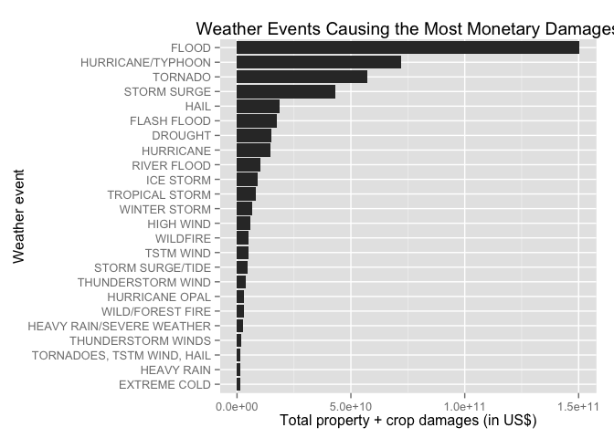

```r
## quick plot of the top damage-causing events and their costs
qplot(x = reorder(EVTYPE, total_damages), y = total_damages,
      data = damages[total_damages >= mean(total_damages)],
      geom = "bar", stat = "identity") +
    coord_flip() +
    labs(title = "Weather Events Causing the Most Monetary Damages",
         x = "Weather event",
         y = "Total property + crop damages (in US$)")
```

**Figure #3**: Plot of total monetary damages by weather event

We see that floods caused the most monetary damages to property and crops, and that tornadoes were the third most costly to property and crops.